[figure not shown]

# Image Scaling using Fourier Transform

Image scaling is commonly achieved using interpolation methods like nearest neighbor, bilinear, or bicubic interpolation. However, in this post, we will tackle the problem using the Fourier Transform, exploring its unique approach to image scaling while addressing various challenges along the way.

Published on February 24, 2022

# Image Scaling with Fast Fourier Transform

# Table of Contents

```python
import numpy as np
from numpy.fft import fft, fft2, ifft, ifft2, fftshift, fftfreq
import matplotlib.pyplot as plt
from matplotlib.animation import FuncAnimation
from IPython.display import HTML
from scipy.ndimage import fourier_gaussian, gaussian_filter
from skimage.transform import resize
```

## Fourier Transform

Fourier transform is used to represent a signal in time domain (or a image in spatial domain) in terms of frequencies. If you are not familiar with Fourier Transform I would recommend checking other online resources before reading this page.

See: https://en.wikipedia.org/wiki/Fourier_transform

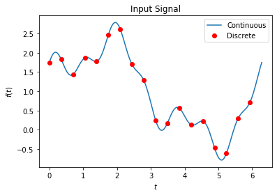

```python
def f(x):
    return 1 + np.sin(x*2+np.pi/3)**2 * np.cos(x*3) + np.sin(x)

N = 18
x = np.linspace(0, 2*np.pi, N, endpoint=False) # "endpoint=False" is important to make the function periodic!
y = f(x)

N_full = 200
x_full = np.linspace(0, 2*np.pi, N_full)
y_full = f(x_full)

plt.plot(x_full, y_full, label="Continuous")
plt.plot(x, y, "or", label="Discrete")
plt.xlabel("$t$")
plt.ylabel("$f(t)$")
plt.title("Input Signal")
_=plt.legend()
```

Analyzing discrete signal in the frequency domain with applying Fourier Transform:

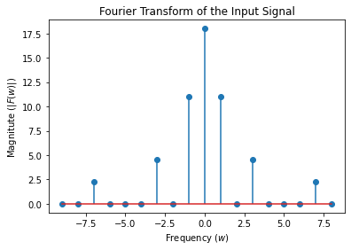

```python
x_freq = fftfreq(len(x), 1/len(x))
y_fft = fft(y)
y_mag = np.abs(y_fft)

plt.xlabel("Frequency ($w$)")
plt.ylabel("Magnitute ($|F(w)|$)")
plt.title("Fourier Transform of the Input Signal")
_=plt.stem(fftshift(x_freq), fftshift(y_mag))
```

Since there are no high frequencies found in the input signal we can pad the zero-centered frequency components array and compute inverse transform to get the interpolated version of the input signal.

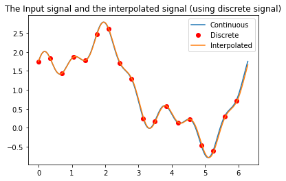

```python
def interpolate_fft_1d(y, new_size): # len(y) and new_size should be even for this function!
    old_size = len(y)
    padding = (new_size-old_size)//2
    y_fft = fftshift( fft(y) )
    y_fft_padded = np.pad(y_fft, padding)
    y_interpolated = ifft(fftshift(y_fft_padded)).real * new_size / old_size
    return y_interpolated

y_interpolated = interpolate_fft_1d(y, N_full)

plt.plot(x_full, y_full, label="Continuous")
plt.plot(x, y, "or", label="Discrete")
plt.plot(x_full, y_interpolated, label="Interpolated")
plt.title("The Input signal and the interpolated signal (using discrete signal)")
_=plt.legend()
```

## Nyquist Frequency, Aliasing & Undersampling

Nyquist Frequency (Folding Frequency) is the smallest frequency needed to sample from a bandlimited signal for correct reconstruction. For example an audio signal with maximum of 22050 Hz frequency needs 44100 sample/second. When the source signal has no upper frequency limits or the sampler has frequency limits using a low pass filter to remove high frequencies would be needed. Folding effect can be seen in the video below.

Example: Sampling from 256x256 image down to 128x128 resolution would cause aliasing problem because of high frequency components. Applying a low pass filter (e.g. Gaussian Filter) before sampling should solve the aliasing problem. This is left to the reader as an exercise. Compare your results with and without applying a Gaussian Filter.

See: https://en.wikipedia.org/wiki/Aliasing#Folding

```python
def animate():
    def update(frame):
        ax1.clear()
        ax2.clear()
        ax3.clear()

        frequency = frame
        N1 = 20
        N2 = 1000

        x_ = np.linspace(0, 2*np.pi, N1, endpoint=False)
        y_ = np.sin(x_ * frequency)
        x_original = np.linspace(0, 2*np.pi, N2, endpoint=False)
        y_original = np.sin(x_original * frequency)
        y_interp = interpolate_fft_1d(y_, N2)

        ax1.set_title("Original Signal: $f(t) = sin(t*{})$".format(frequency))
        ax1.set_ylim(-1, 1)
        ax1.plot(x_original, y_original)
        ax2.set_title("Reconstruction from Samples")
        ax2.set_ylim(-1, 1)
        ax2.plot(y_interp)
        ax3.set_title("Fourier Transform of the Sampled Signal")
        ax3.set_ylim(-1, N1/2+5)
        ax3.stem(np.abs(fftshift(fft(y_))))
        fig.suptitle("Original Signal Frequency: {} Hz, Sample Size: {}".format(frequency, N1))
        fig.tight_layout()

    fig, (ax1, ax2, ax3) = plt.subplots(1,3, figsize=(14, 3))
    ani = FuncAnimation(fig, update, frames=range(1, 50), init_func=None, blit=False, interval=333)
    video = ani.to_html5_video()
    plt.close()
    return video

HTML(animate())
```

[video not shown]

## Gaussian Filter

Gaussian filter is a low pass filter. We are trying Gaussian Filter (in frequency domain) with an example below. High frequencies vanished but values are still not zero (maybe zero because of discrete computation accuracy).

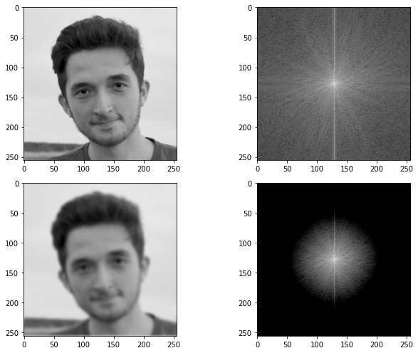

```python
img = plt.imread("portrait.png")
fft_img = np.log10(np.abs(fftshift(fft2(img))))
img_filtered = ifft2(fourier_gaussian(fft2(img), sigma=2)).real
fft_img_filtered = np.log10(np.abs(fftshift(fft2(img_filtered))))

fig, ((ax1, ax2), (ax3, ax4)) = plt.subplots(2, 2, figsize=(10, 7))
ax1.imshow(img, vmax=1, vmin=0, cmap="gray")
ax2.imshow(fft_img, cmap="gray")
ax3.imshow(img_filtered, vmax=1, vmin=0, cmap="gray")
ax4.imshow(fft_img_filtered, cmap="gray", vmin=fft_img.min(), vmax=fft_img.max())
fig.tight_layout()
```

## Downscaling with Sinc Filter

Sinc and box filters are also low pass filters. Box filter on spatial domain is obtained as sinc in the frequency domain. Also, sinc filter is obtained as box in the frequency domain. Applying sinc filter is pretty easy then, isn't it?

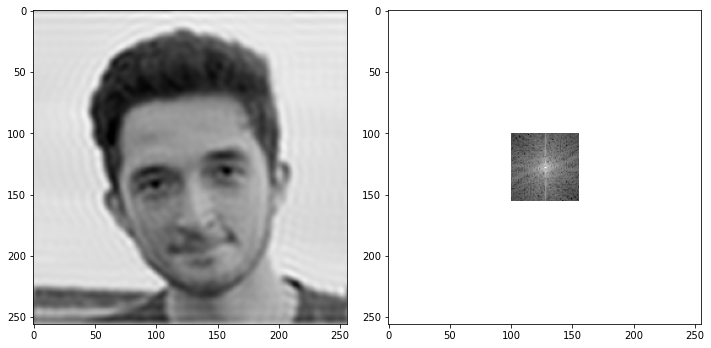

```python
img_fft = fftshift(fft2(img))
N = 100
img_fft[:N, :] = 0
img_fft[-N:] = 0
img_fft[:, :N] = 0
img_fft[:, -N:] = 0

img_filtered = ifft2(fftshift(img_fft)).real

fig, (ax1, ax2) = plt.subplots(1, 2, figsize=(10, 5))
ax1.imshow(img_filtered, vmax=1, vmin=0, cmap="gray")
ax2.imshow(np.log10(np.abs(img_fft)), cmap="gray")
fig.tight_layout()
```

Let's remove the outer part with zeros then compute the inverse fft. As a result the output signal will be smaller. Let's summarize the idea by cropping the border instead of setting zero values.

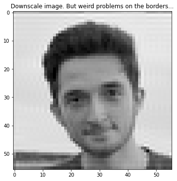

```python
def downscale_fft_v1(img, N):
    fft_ = fft2(img)
    fft_ = fftshift(fft_)
    fft_ = fft_[N:-N, N:-N]
    fft_ = fftshift(fft_)
    img_new = ifft2(fft_).real
    return img_new * (np.prod(img_new.shape)/np.prod(img.shape))

plt.subplots(figsize=(6,6))
img_new = downscale_fft_v1(img, 100)
plt.title("Downscale image. But weird problems on the borders...")
_=plt.imshow(img_new, cmap="gray", vmin=0, vmax=1)
```

```python
def animate():
    fig = plt.figure(figsize=(8, 8))
    ax = fig.add_subplot(111)

    def update(frame):
        ax.clear()
        ax.set_axis_off()
        ax.set_aspect(1)

        img_new = downscale_fft_v1(img, frame)
        plt.imshow(img_new, cmap="gray", vmin=0, vmax=1)
        plt.title("Size = ({}, {})".format(*img_new.shape))

        ax.margins(x=0, y=0)
        fig.tight_layout()

    ani = FuncAnimation(fig, update, frames=range(1, 127), init_func=None, blit=False, interval=66)
    video = ani.to_html5_video()
    plt.close()
    return video

HTML(animate())
```

[video not shown]

## Problem: Overshooting on Borders

What is happening on some edges? It looks like edges on the opposite sides are affecting each other. Actually... This is happening because images are periodic signals. Showing this via numpy functions is difficult. So, I will be demonstrating the periodicity via an implementation of fourier transform. First I will show you fourier functions I have implemented.

$$ X_k = \sum_{n=0}^{N-1}{x_n \cdot e^{-\frac{i2\pi}{N}kn}} $$

$$ x_n = \frac{1}{N} \sum_{k=0}^{N-1} X_k \cdot e^{i \frac{2\pi}{N}kn} $$

See:

- https://en.wikipedia.org/wiki/Discrete_Fourier_transform#Definition
- https://en.wikipedia.org/wiki/Discrete_Fourier_transform#Inverse_transform

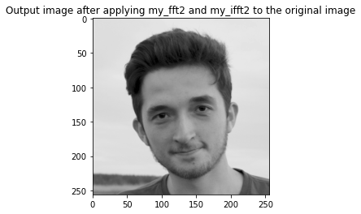

```python
def my_dft(arr):
    N = arr.shape[0]
    n = np.arange(N)
    k = np.arange(0, N).reshape((N,1))
    return np.dot(np.exp(-2j*np.pi*n*k/N), arr)

def my_idft(arr):
    N = arr.shape[0]
    n = np.arange(0, N)
    k = np.arange(0, N).reshape((N,1))
    return 1/N * np.dot(np.exp(2j*np.pi*n*k/N), arr)

def my_dft2(arr):
    return my_dft(my_dft(arr).T).T

def my_idft2(arr):
    return my_idft(my_idft(arr).T).T

my_img = my_idft2(my_dft2(img)).real # similar to np.fft.fft2 and np.fft.ifft2

plt.title("Output image after applying my_fft2 and my_ifft2 to the original image")
_=plt.imshow(my_img, vmin=0, vmax=1, cmap="gray")
```

But what if we compute...

$$ \hat x_n = \frac{1}{N} \sum_{k=-\frac{N}{2}}^{\frac{3N}{2}} X_k \cdot e^{i \frac{2\pi}{N}kn} $$

Since the image is periodic it repeats itself.

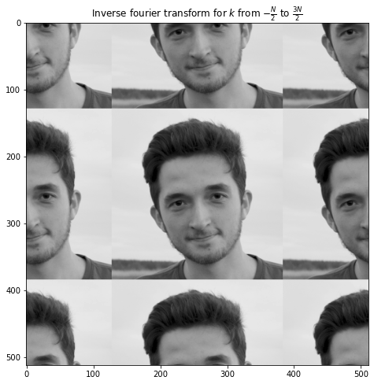

```python
def my_idft_modified(arr):
    N = arr.shape[0]
    n = np.arange(0, N)
    k = np.arange(0, N*2).reshape((N*2,1)) - N//2
    return 1/N * np.dot(np.exp(2j*np.pi*n*k/N), arr)

def my_idft2_modified(arr):
    return my_idft_modified(my_idft_modified(arr).T).T

my_img = my_idft2_modified(my_dft2(img)).real

plt.subplots(figsize=(8,8))
plt.title(r'Inverse fourier transform for $k$ from $-\frac{N}{2}$ to $\frac{3N}{2}$')
_=plt.imshow(my_img, vmin=0, vmax=1, cmap="gray")
```

But this periodicity is causing problems on borders. It is because of the "Gibbs phenomenon" which says it is impossible to represent discontinuities via Fourier series with finite length.

See for more: https://en.wikipedia.org/wiki/Gibbs_phenomenon and https://en.wikipedia.org/wiki/Ringing_artifacts

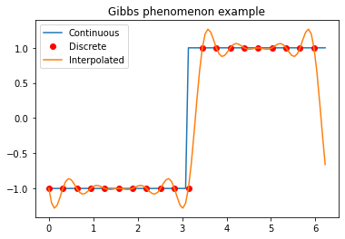

```python
def f(x):
    return np.where(x>np.pi, 1, -1)

N = 20
x = np.linspace(0, 2*np.pi, N, endpoint=False) # "endpoint=False" is important to make the function periodic!
y = f(x)

N_full = 100
x_full = np.linspace(0, 2*np.pi, N_full, endpoint=False)
y_full = f(x_full)
y_interpolated = interpolate_fft_1d(y, N_full)

plt.plot(x_full, y_full, label="Continuous")
plt.plot(x, y, "or", label="Discrete")
plt.plot(x_full, y_interpolated, label="Interpolated")
plt.title("Gibbs phenomenon example")
_=plt.legend()
```

Padding the original image may help to overcome sudden changes. After applying Fourier Transform on to the padded image we can apply cropping afterwards.

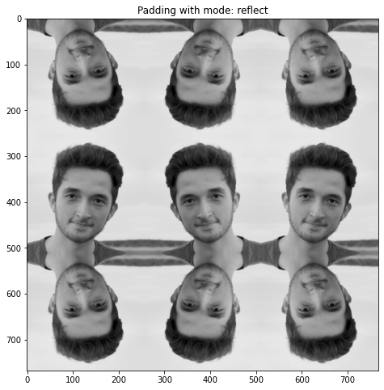

```python
img_new = np.pad(img, img.shape, mode='reflect')
plt.subplots(figsize=(8,8))
plt.title("Padding with mode: reflect")
_=plt.imshow(img_new, cmap="gray", vmin=0, vmax=1)
```

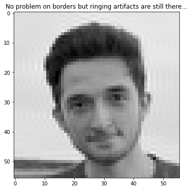

```python
def downscale_fft_v2(img, N):
    img_ = np.pad(img, img.shape, mode='reflect')
    fft_ = fft2(img_)
    fft_ = fftshift(fft_)
    fft_ = fft_[N*3:-N*3, N*3:-N*3]
    fft_ = fftshift(fft_)
    img_new = ifft2(fft_).real
    img_new_ = img_new[img_new.shape[0]//3:-img_new.shape[0]//3, img_new.shape[1]//3:-img_new.shape[1]//3]
    return img_new_ * (np.prod(img_new.shape)/np.prod(img_.shape))

plt.subplots(figsize=(6,6))
img_new = downscale_fft_v2(img, 100)
plt.title("No problem on borders but ringing artifacts are still there...")
_=plt.imshow(img_new, cmap="gray", vmin=0, vmax=1)
```

```python
def animate():
    fig = plt.figure(figsize=(8, 8))
    ax = fig.add_subplot(111)

    def update(frame):
        ax.clear()
        ax.set_axis_off()
        ax.set_aspect(1)

        img_new = downscale_fft_v2(img, frame)
        plt.imshow(img_new, cmap="gray", vmin=0, vmax=1)
        plt.title("Size = ({}, {})".format(*img_new.shape))

        ax.margins(x=0, y=0)
        fig.tight_layout()

    ani = FuncAnimation(fig, update, frames=range(1, 120), init_func=None, blit=False, interval=66)
    video = ani.to_html5_video()
    plt.close()
    return video

HTML(animate())
```

[video not shown]

## Problem: Ringing Artifacts

Low pass filter is a solution for this problem. So we will be applying a Gaussian Filter to the output image.

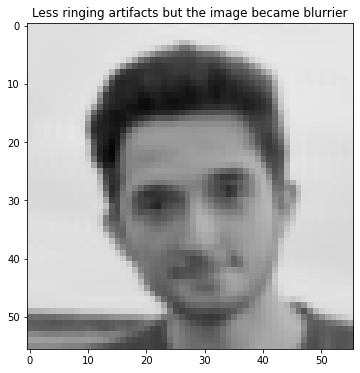

```python
def downscale_fft_v3(img, N, sigma):
    img_ = np.pad(img, img.shape, mode='reflect')
    fft_ = fft2(img_)
    fft_ = fftshift(fft_)
    fft_ = fft_[N*3:-N*3, N*3:-N*3]
    fft_ = fftshift(fft_)
    img_new = ifft2(fft_).real
    img_new_ = img_new[img_new.shape[0]//3:-img_new.shape[0]//3, img_new.shape[1]//3:-img_new.shape[1]//3]
    img_new_ = img_new_ * (np.prod(img_new.shape)/np.prod(img_.shape))
    return gaussian_filter(img_new_, sigma=sigma)

plt.subplots(figsize=(6,6))
img_new = downscale_fft_v3(img, 100, 0.6)
plt.title("Less ringing artifacts but the image became blurrier")
_=plt.imshow(img_new, cmap="gray", vmin=0, vmax=1)
```

```python
def animate():
    fig = plt.figure(figsize=(8, 8))
    ax = fig.add_subplot(111)

    def update(frame):
        ax.clear()
        ax.set_axis_off()
        ax.set_aspect(1)

        img_new = downscale_fft_v3(img, frame, frame/150)
        plt.imshow(img_new, cmap="gray", vmin=0, vmax=1)
        plt.title("Size = ({}, {})".format(*img_new.shape))

        ax.margins(x=0, y=0)
        fig.tight_layout()

    ani = FuncAnimation(fig, update, frames=range(1, 120), init_func=None, blit=False, interval=66)
    video = ani.to_html5_video()
    plt.close()
    return video

HTML(animate())
```

[video not shown]

## Let's Try Something Weird

It feels like removing those high frequencies seems bad in general. Maybe we can use the idea of aliasing: Spectral Folding. Let's create the problem by ourselves.

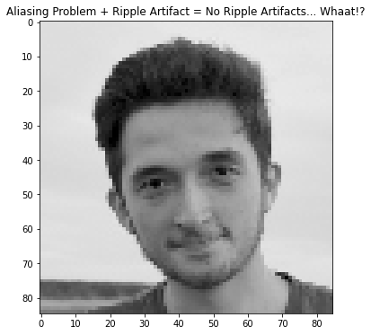

```python
def downscale_fft_experimental(img, N):
    fft_ = fft2(img)
    fft_ = fftshift(fft_)
    fft__ = fft_[N:-N-1, N:-N-1]
    M = fft__.shape[0]
    fft__ += fft_[0:M, 0:M]
    fft__ += fft_[-M-1:-1, -M-1:-1]
    fft__ += fft_[0:M, -M:]
    fft__ += fft_[-M-1:-1, 0:M]
    fft__ += fft_[N:-N-1, 0:M]
    fft__ += fft_[N:-N-1, -M-1:-1]
    fft__ += fft_[0:M, N:-N-1]
    fft__ += fft_[-M-1:-1, N:-N-1]
    fft_ = fftshift(fft__)
    img_new = ifft2(fft_).real
    return img_new * (np.prod(img_new.shape)/np.prod(img.shape))

plt.subplots(figsize=(6,6))
img_new = downscale_fft_experimental(img, 85)
plt.title("Aliasing Problem + Ripple Artifact = No Ripple Artifacts... Whaat!?")
_=plt.imshow(img_new, cmap="gray", vmin=0, vmax=1)
```

Just kidding! Actually this is not much different that sampling of the original image. So this will stay as a weird way of sampling of an image.

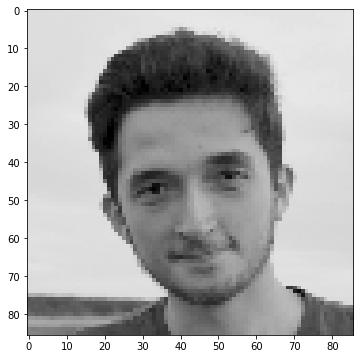

```python
img_new = img[::3, ::3]
plt.subplots(figsize=(6,6))
_=plt.imshow(img_new, cmap="gray", vmin=0, vmax=1)
```

## Upscaling

Applying zero padding on zero-centered 2D frequency domain is a way to solve the upscaling task. Similar to `interpolate_fft_1d` function but 2D. Unfortunately ringing artifacts and overshooting may still occur. This task is left to the reader as an exercise.

## Final Thoughts

Ringing artifacts are pain if we want to solve image scaling task with Fourier Transform. A low pass filter (e.g. Guassian filter) can be used after scaling but it is causing the image to be blurry. Other than blurring problem Fourier Series is not a good way to represent discontinuities and causing overshooting so that pixel values may go out of $[0,1]$ range. This may be solved via clipping but this doesn't solve the problem completely.

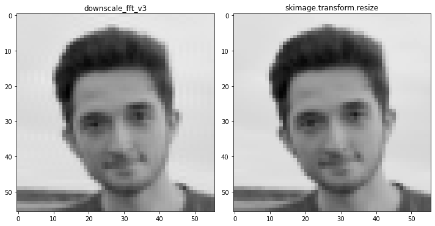

```python
fig, (ax1, ax2) = plt.subplots(1, 2, figsize=(10,5))
img_new1 = downscale_fft_v3(img, 100, 0.5)
ax1.imshow(img_new1, cmap="gray", vmin=0, vmax=1)
ax1.set_title("downscale_fft_v3")
img_new2 = resize(img, img_new1.shape)
ax2.imshow(img_new2, cmap="gray", vmin=0, vmax=1)
ax2.set_title("skimage.transform.resize")
fig.tight_layout()
```